# IE_360_homework_1

Omer Erhan Erbis

11/19/2020

First of all, we load required libraries for data importing (Quandl and gtrendsR) for measure values and Google Trends values (max is stretched to 100, min is stretched to 0). I also include quantmod to use chartSeries plots.

I choose gold prices (GOLD), oil prices (OIL) and Microsoft share prices(MSFT) as my 3 measures.

Some data manipulation (year ordering) and assignments are below.

```r
library(Quandl)
library(quantmod)
library(gtrendsR)
Quandl.api_key("27uxjqL9o-tRDCUy_wxS")


# Measures of Interest by Quandl package
MSFT <- Quandl("EOD/MSFT", type = "xts")
head(MSFT)
OIL <- Quandl("OPEC/ORB", type = "xts")
head(OIL)
GOLD <- Quandl("LBMA/GOLD", type = "xts")
head(GOLD)


# Google Trends Data with gtrendsR package
GOLD_GTRENDS <- gtrends(keyword = "GOLD", time = "2018-01-01 2020-11-18")
GOLD_GTRENDS_interest <- xts(GOLD_GTRENDS$interest_over_time$hits, order.by = GOLD_GTRENDS$interest_over_time$date)
colnames(GOLD_GTRENDS_interest) <- c("GOLD_hits")
GOLD_GTRENDS_interest <- GOLD_GTRENDS_interest[nrow(GOLD_GTRENDS_interest):1]
OIL_GTRENDS <- gtrends(keyword = "OIL", time = "2018-01-01 2020-11-18")
OIL_GTRENDS_interest <- xts(OIL_GTRENDS$interest_over_time$hits, order.by = OIL_GTRENDS$interest_over_time$date)
colnames(OIL_GTRENDS_interest) <- c("OIL_hits")
OIL_GTRENDS_interest <- OIL_GTRENDS_interest[nrow(OIL_GTRENDS_interest):1]
MSFT_GTRENDS <- gtrends(keyword = "MSFT", time = "2015-01-01 2017-12-28")
MSFT_GTRENDS_interest <- xts(MSFT_GTRENDS$interest_over_time$hits, order.by = MSFT_GTRENDS$interest_over_time$date)
colnames(MSFT_GTRENDS_interest) <- c("MSFT_hits")
MSFT_GTRENDS_interest <- MSFT_GTRENDS_interest[nrow(MSFT_GTRENDS_interest):1]
```

```r
head(GOLD_GTRENDS_interest)
```

```
##            GOLD_hits
## 2018-01-07        57
## 2018-01-14        56
## 2018-01-21        56
## 2018-01-28        58
## 2018-02-04        58
## 2018-02-11        64
```

```r
head(OIL_GTRENDS_interest)
```

```
##            OIL_hits
## 2018-01-07       58
## 2018-01-14       55
## 2018-01-21       55
## 2018-01-28       56
## 2018-02-04       56
## 2018-02-11       55
```

```r
head(MSFT_GTRENDS_interest)
```

```
##            MSFT_hits
## 2015-01-04        26
## 2015-01-11        29
## 2015-01-18        39
## 2015-01-25        76
## 2015-02-01        46
## 2015-02-08        37
```

We use to.yearly to find the timestamps for year ends. I only used 3 years for each measures. Additional years can be done in the same way. For ease, each year ebd are assigned to relative objects.

```r
GOLD_end_2020 <- which(index(GOLD)=="2020-11-18")
GOLD_end_2019 <- which(index(GOLD)=="2019-12-31")
GOLD_end_2018 <- which(index(GOLD)=="2018-12-31")
GOLD_end_2017 <- which(index(GOLD)=="2017-12-29")

OIL_end_2020 <- which(index(OIL)=="2020-11-18")
OIL_end_2019 <- which(index(OIL)=="2019-12-31")
OIL_end_2018 <- which(index(OIL)=="2018-12-28")
OIL_end_2017 <- which(index(OIL)=="2017-12-29")

MSFT_end_2017 <- which(index(MSFT)=="2017-12-28")
MSFT_end_2016 <- which(index(MSFT)=="2016-12-30")
MSFT_end_2015 <- which(index(MSFT)=="2015-12-31")
MSFT_end_2014 <- which(index(MSFT)=="2014-12-31")
```

```r
to.yearly(GOLD[,1])
```

```
##            GOLD[, 1].Open GOLD[, 1].High GOLD[, 1].Low GOLD[, 1].Close
## 1968-12-31          35.18          42.60         35.14           41.95
## 1969-12-31          41.80          43.75         35.00           35.21
## 1970-12-31          35.12          39.19         34.77           37.38
## 1971-12-31          37.33          43.90         37.33           43.62
## 1972-12-29          43.73          70.00         43.73           64.70
## 1973-12-31          64.99         127.00         64.10          112.25
## 1974-12-31         114.75         197.50        114.75          187.50
## 1975-12-31         185.00         186.25        128.75          140.25
## 1976-12-31         140.35         140.35        103.05          134.55
## 1977-12-30         136.10         168.15        129.40          165.60
## 1978-12-29         168.60         243.65        166.30          224.50
## 1979-12-31         227.15         524.00        216.55          524.00
## 1980-12-31         559.00         843.00        474.00          589.50
## 1981-12-31         592.00         599.25        391.75          400.00
## 1982-12-31         399.00         488.50        297.00          448.00
## 1983-12-30         452.75         511.50        374.75          381.50
## 1984-12-31         384.00         406.85        303.25          309.00
## 1985-12-31         306.25         339.30        285.00          327.00
## 1986-12-31         327.10         442.75        326.00          390.90
## 1987-12-31         402.40         502.75        392.60          486.50
## 1988-12-30         484.10         485.30        389.05          410.15
## 1989-12-29         413.60         417.15        358.10          401.00
## 1990-12-31         401.65         421.40        346.75          391.00
## 1991-12-31         392.50         403.70        343.50          353.40
## 1992-12-31         351.20         359.30        330.20          332.90
## 1993-12-31         329.40         406.70        326.50          390.65
## 1994-12-30         395.00         397.50        370.25          382.50
## 1995-12-29         381.40         396.95        372.45          386.70
## 1996-12-31         387.10         416.25        368.30          369.55
## 1997-12-31         367.80         367.80        283.05          289.20
## 1998-12-31         287.70         314.60        273.40          287.45
## 1999-12-30         288.25         326.25        252.90          290.85
## 2000-12-29         282.05         316.60        263.80          272.65
## 2001-12-31         272.80         292.85        256.70          276.50
## 2002-12-31         278.10         348.50        277.80          342.75
## 2003-12-31         342.20         417.25        319.75          417.25
## 2004-12-31         415.20         455.75        373.50          438.00
## 2005-12-30         426.80         537.50        411.50          513.00
## 2006-12-29         520.75         725.75        520.75          635.70
## 2007-12-31         640.75         841.75        608.30          836.50
## 2008-12-31         840.75        1023.50        692.50          865.00
## 2009-12-31         869.75        1218.25        813.00         1104.00
## 2010-12-31        1113.00        1426.00       1052.25         1410.25
## 2011-12-30        1405.50        1896.50       1316.00         1574.50
## 2012-12-31        1590.00        1790.00       1537.50         1664.00
## 2013-12-31        1681.50        1692.50       1192.75         1201.50
## 2014-12-31        1219.75        1379.00       1144.50         1199.25
## 2015-12-31        1184.25        1298.00       1050.60         1062.25
## 2016-12-30        1072.70        1370.00       1072.70         1159.10
## 2017-12-29        1148.65        1350.90       1148.65         1296.50
## 2018-12-31        1312.80        1360.25       1176.70         1281.65
## 2019-12-31        1287.20        1542.60       1270.05         1523.00
## 2020-11-18        1520.55        2061.50       1472.35         1877.20
```

```r
to.yearly(OIL[,1])
```

```
##            OIL[, 1].Open OIL[, 1].High OIL[, 1].Low OIL[, 1].Close
## 2003-12-31         30.05         33.11        23.27          29.87
## 2004-12-31         29.41         46.61        28.09          36.43
## 2005-12-30         35.67         61.37        35.67          53.47
## 2006-12-29         55.60         72.68        53.37          55.97
## 2007-12-31         56.16         91.77        47.97          90.70
## 2008-12-31         91.82        140.73        33.36          35.58
## 2009-12-31         40.44         77.88        38.10          77.16
## 2010-12-31         78.23         90.73        66.84          88.99
## 2011-12-30         89.81        120.91        89.81         106.84
## 2012-12-31        109.40        124.64        88.74         107.76
## 2013-12-31        108.96        114.94        96.35         107.94
## 2014-12-31        106.85        110.48        52.00          52.00
## 2015-12-31         51.78         64.96        30.74          31.27
## 2016-12-30         31.79         53.46        22.48          53.30
## 2017-12-29         53.13         64.47        42.58          64.47
## 2018-12-28         64.84         84.09        50.11          51.55
## 2019-12-31         52.14         74.04        52.14          67.96
## 2020-11-18         67.12         70.87        12.22          43.05
```

```r
to.yearly(MSFT[,4])
```

```
##            MSFT[, 4].Open MSFT[, 4].High MSFT[, 4].Low MSFT[, 4].Close
## 2013-12-31          31.88          38.94        31.152           37.41
## 2014-12-31          37.16          49.61        34.980           46.45
## 2015-12-31          46.76          56.55        40.290           55.48
## 2016-12-30          54.80          63.62        48.430           62.14
## 2017-12-28          62.58          86.85        62.300           85.72
```

### Gold plots:

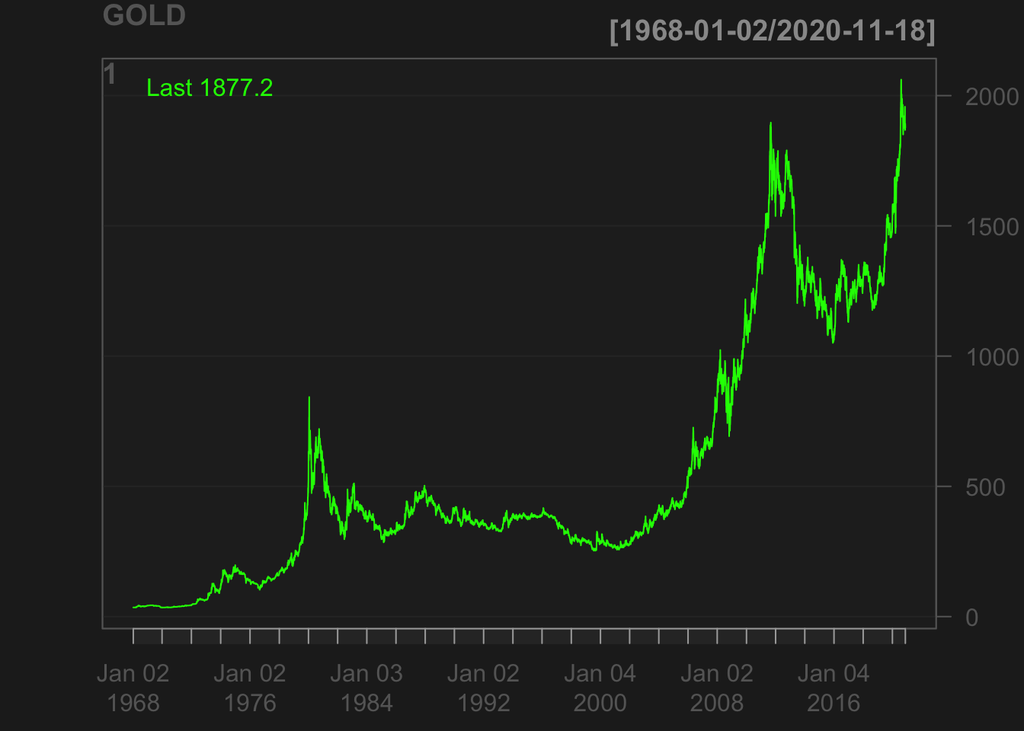

```r
# GOLD plots
par(mfrow = c(1,1))
chartSeries(GOLD[,1], main= "GOLD")
```

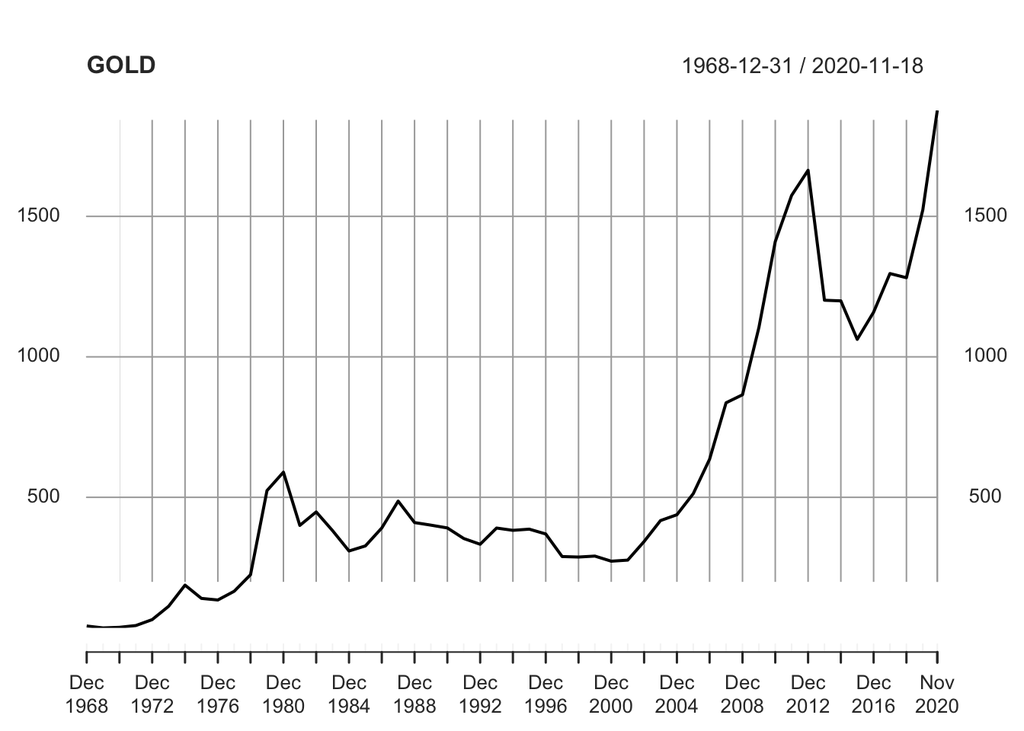

```r
plot(to.yearly(GOLD[,1])[,4], main = "GOLD")
```

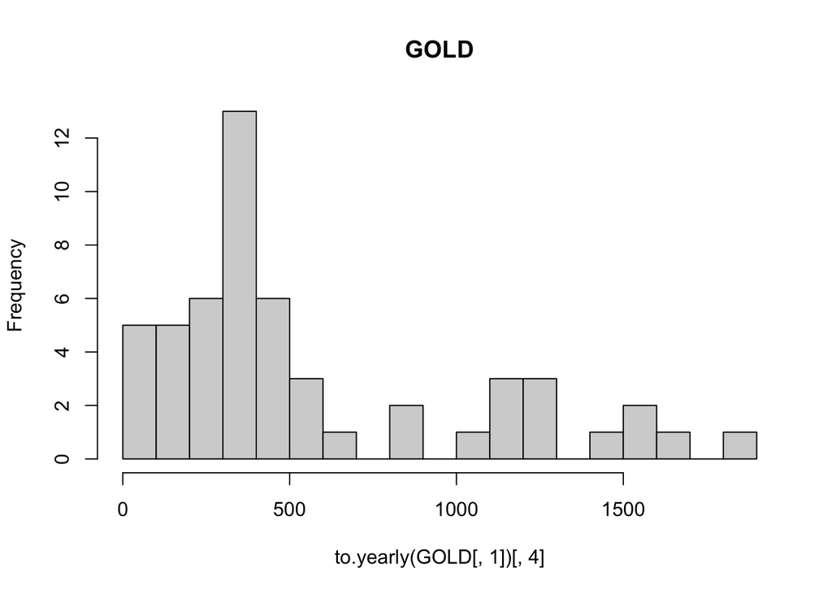

```r
hist(to.yearly(GOLD[,1])[,4], breaks = 25, main = "GOLD")
```

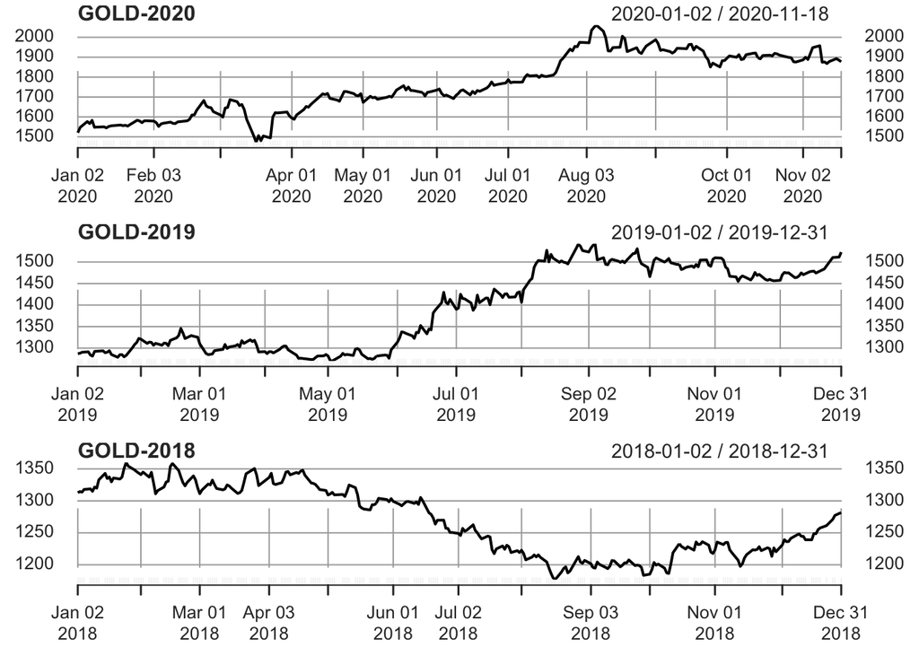

```r
par(mfrow = c(3,1))
plot(GOLD[(GOLD_end_2019+1):GOLD_end_2020, 1], main = "GOLD-2020")
plot(GOLD[(GOLD_end_2018+1):GOLD_end_2019, 1], main = "GOLD-2019")
plot(GOLD[(GOLD_end_2017+1):GOLD_end_2018, 1], main = "GOLD-2018")
```

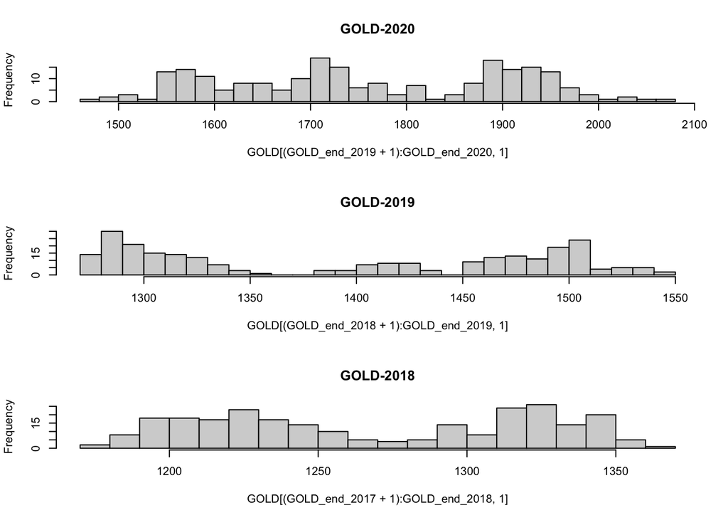

```r
par(mfrow = c(3,1))
hist(GOLD[(GOLD_end_2019+1):GOLD_end_2020, 1], breaks = 25, main = "GOLD-2020")
hist(GOLD[(GOLD_end_2018+1):GOLD_end_2019, 1], breaks = 25, main = "GOLD-2019")
hist(GOLD[(GOLD_end_2017+1):GOLD_end_2018, 1], breaks = 25, main = "GOLD-2018")
```

2018 differs from 2019 and 2020 in overall shape. There are several reasons that affect the gold prices in those times and the difference may result from them. Additionally, histograms show some similarity regarding frequency distributions. However, 2020 slightly diverges from other years as global uncertainties and tensions rose with regional conflicts and Covid-19.